# Predicting Hospital Exit

Catherine and Gi’s project

Summary & intepretation

Catherine Ishitani , Gi Kim (Wharton)  
March 31, 2021

## Overview

In our final post, we do two things:

1. we summarize our prior predictive findings, reframing model performance in terms of Type 1 and Type 2 error loss;
2. we perform additional analyses to better interpret our findings about which variables are “important” for predicting hospital exit.

Specifically, we try to gain some intuition about how REEMtree works by re-estimating our predictive models using “de-meaned” data. (In a linear probability model, this could potentially approximate including a hospital “fixed effect,” leaving only within-variation). We run 3 algorithmic models on de-meaned data and compare their variable importance plots to those generated by the REEMtree approach on the original data.

Next, we try to estimate the effects of the most consistently “important” variables on hospital exit. We employ double machine learning methods using the DoubleML package by Bach, Chernozhukov, Kurz, and Spindler and bechmark them against a “naive” approach. Finally, we consider how our results support our competing hypotheses about profit versus liquidity constrained closures.

## Summary of prediction error

In our prior post, we ran 5 algorithmic models to predict hospital exit: LASSO, CART, REEMTree, random forest, and Boosted trees.

We plot ROC curves (accuracy against Type 2 error) of all 5 models, and calculate the AUC measure of each.

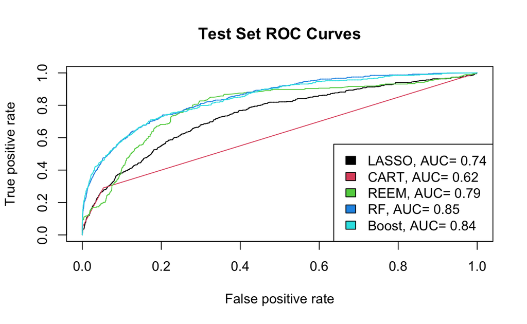

```r
train <- readRDS("model_train.rds")
# LASSO
lasso_model <- readRDS("lasso_model.rds")
lasso_test <- readRDS("lasso_test.rds")
lasso_result <- readRDS("lasso_result.rds")
lasso_pred <- predict(lasso_model, s=lasso_model$lambda, newx = lasso_test)
lasso_rocr_pred<- prediction(lasso_pred,as.vector(lasso_result))

# CART
cart_model <- readRDS("cart_model.rds")
cart_test <- readRDS("cart_test.rds")
cart_pred<- predict(cart_model, cart_test)
cart_rocr_pred<- prediction(cart_pred,as.vector(cart_test$exit_outcome))

# REEM
reem_model <- readRDS("reem_model.rds")
reem_test <- readRDS("reem_test.rds")
reem_pred<- predict(reem_model, reem_test, id=reem_test$num_prvdr_num, EstimateRandomEffects=TRUE)
reem_rocr_pred<- prediction(reem_pred,as.vector(reem_test$exit_outcome))

# Random Forest
rf_model <- readRDS("rf_model.rds")
rf_test <- readRDS("rf_test.rds")
rf_pred<- predict(rf_model, rf_test)
rf_rocr_pred<- prediction(rf_pred$predictions,as.vector(rf_test$exit_outcome))

# Boost
boost_model <- readRDS("boost_model.rds")
boost_test <- readRDS("boost_test.rds")
boost_pred <- predict(boost_model, as.matrix(boost_test%>% dplyr::select(-exit_outcome)))
boost_rocr_pred <- prediction(boost_pred,as.vector(boost_test$exit_outcome))

# List of predictions and test
model_list <-list(lasso_model, cart_model, reem_model, rf_model, boost_model)
m <- length(model_list)
actual_list <- rep(list(train), m)

# Plot ROC (x- Type1, y-Type2)
preds <- list(lasso_rocr_pred, cart_rocr_pred, reem_rocr_pred, rf_rocr_pred, boost_rocr_pred)
rocs <- lapply(preds,performance, "tpr", "fpr")
aucs <- lapply(preds,performance, "auc")

plot(rocs[[1]], col = 1, main = "Test Set ROC Curves")
plot(rocs[[2]], col = 2, main = "Test Set ROC Curves", add=TRUE)
plot(rocs[[3]], col = 3, main = "Test Set ROC Curves", add=TRUE)
plot(rocs[[4]], col = 4, main = "Test Set ROC Curves", add=TRUE)
plot(rocs[[5]], col = 5, main = "Test Set ROC Curves", add=TRUE)
legend(x = "bottomright", legend = c(paste("LASSO, AUC=",round(aucs[[1]]@y.values[[1]],2)),
                                     paste("CART, AUC=",round(aucs[[2]]@y.values[[1]],2)),
                                     paste("REEM, AUC=",round(aucs[[3]]@y.values[[1]],2)),
                                     paste("RF, AUC=",round(aucs[[4]]@y.values[[1]],2)),
                                     paste("Boost, AUC=",round(aucs[[5]]@y.values[[1]],2))), fill = 1:m)
```

## Variable importance: demeaned data

**1. CART**

As usual, we created training and test samples.

```r
#remove some id vars & unused vars
cleaned <- select(hcris, -c(outcome_new,num_prvdr_num,cont,sysid))

# Create reproducible training (70%) and test (30%) sets.
set.seed(123)
hosp_split <- initial_split(cleaned, prop = .7)
hosp_train <- training(hosp_split)
hosp_test  <- testing(hosp_split)
```

Then, we ran a tree using the CART algorithm on the training sample. Lo and behold, we found a *much* richer and deeper tree than before. (The CART model on the original data only had two splits.) Next, we tuned it.

```r
m1 <- rpart(
  formula = exit_outcome ~ .,
  data    = hosp_train,
  method  = "anova"
  )

m1
```

```
n= 60068

node), split, n, deviance, yval
      * denotes terminal node

    1) root 60068 7.427005e+02  0.0001497183
      2) l1_cont< 0.4772727 59757 6.735320e+02 -0.0016468610
        4) mcaid_exp< 0.8090909 59680 6.296104e+02 -0.0024186080
          8) age_enter< 0.8571432 32714 1.241350e+02 -0.0161092600
           16) uninsur< 2.20336e-08 4812 7.792067e+01 -0.0701067600
             32) uninsur>=-5.042676e-08 1016 2.575576e+01 -0.2398954000
               64) enter>=-0.4166667 1000 1.685650e+01 -0.2517337000 *
               65) enter< -0.4166667 16 0.000000e+00  0.5000000000 *
             33) uninsur< -5.042676e-08 3796 1.503615e+01 -0.0246628000 *
           17) uninsur>=2.20336e-08 27902 2.976417e+01 -0.0067968070 *
          9) age_enter>=0.8571432 26966 4.919049e+02  0.0141903000
           18) year>=2006.5 26792 4.296709e+02  0.0112625700
             36) p_hist_downsize>=-0.3604062 26737 4.066543e+02  0.0102602800
               72) cah< 0.6507937 26730 4.008973e+02  0.0100229100
                144) l1_cont< 0.06904763 19083 3.190277e+01  0.0010096250 *
                145) l1_cont>=0.06904763 7647 3.635755e+02  0.0325154600
                  290) age_enter< 2.477273 2500 3.560723e+01 -0.0206750900 *
                  291) age_enter>=2.477273 5147 3.174596e+02  0.0583511600
                    582) year>=2009.5 5014 2.570217e+02  0.0449225900
                     1164) l1_cont>=0.1291667 4113 9.314766e+01  0.0208305300
                       2328) l1_enter>=-0.08712121 3420 2.829179e+01  0.0062827080 *
                       2329) l1_enter< -0.08712121 693 6.056004e+01  0.0926249900
                         4658) year>=2015.5 486 1.152995e+01  0.0243182900 *
                         4659) year< 2015.5 207 4.143861e+01  0.2529973000
                           9318) age_enter< 3.278409 126 1.114429e+01  0.0519312700
                            18636) enter>=-0.1339286 108 3.281068e-01 -0.0541666700 *
                            18637) enter< -0.1339286 18 2.306067e+00  0.6885189000 *
                           9319) age_enter>=3.278409 81 1.727665e+01  0.5657666000
                            18638) enter>=-0.1055556 49 1.194231e+01  0.3584415000
                              37276) age_enter< 4.25 27 1.674931e-02 -0.0868686900 *
                              37277) age_enter>=4.25 22 4.507880e-04  0.9049586000 *
                            18639) enter< -0.1055556 32 3.023453e-03  0.8832330000 *
                     1165) l1_cont< 0.1291667 901 1.505889e+02  0.1549011000
                       2330) age_hosp< 3.75 395 1.754532e+01 -0.0261834000
                         4660) l1_cont< 0.1180556 375 4.364191e-01 -0.0742465100 *
```

[output cut: 13 more lines]

```
               73) cah>=0.6507937 7 4.227576e-03  0.9166928000 *
             37) p_hist_downsize< -0.3604062 55 9.932779e+00  0.4984993000 *
           19) year< 2006.5 174 2.664321e+01  0.4649947000
             38) l1_cont< 0.2403846 43 3.948575e+00 -0.0377617200 *
             39) l1_cont>=0.2403846 131 8.258149e+00  0.6300216000 *
        5) mcaid_exp>=0.8090909 77 1.633645e+01  0.5965067000
         10) age_hosp< 5.441559 30 5.610555e+00  0.1877169000 *
         11) age_hosp>=5.441559 47 2.512659e+00  0.8574363000 *
      3) l1_cont>=0.4772727 311 3.191518e+01  0.3453529000
        6) year>=2015.5 86 1.917033e+00  0.0263289000 *
        7) year< 2015.5 225 1.789988e+01  0.4672910000
         14) age_enter< 0.875 163 1.253782e+01  0.3831727000
           28) enter< -0.225 26 1.178621e+00 -0.2074176000 *
           29) enter>=-0.225 137 5.694161e-01  0.4952555000 *
         15) age_enter>=0.875 62 1.176438e+00  0.6884408000 *
```

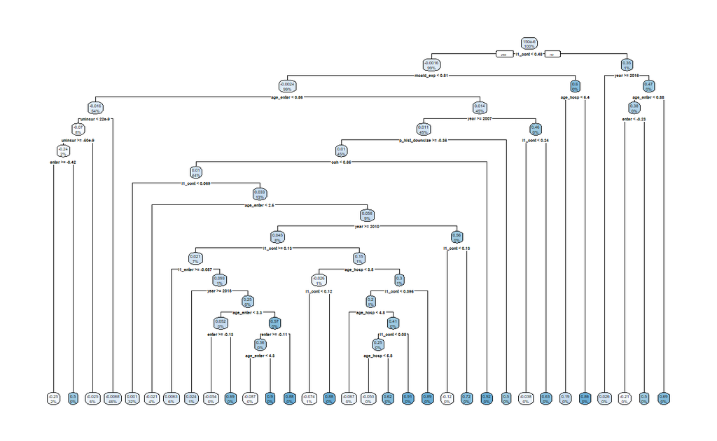

```r
rpart.plot(m1)
```

Our cross validation plot indicates that the optimal tree now has over 20 splits.

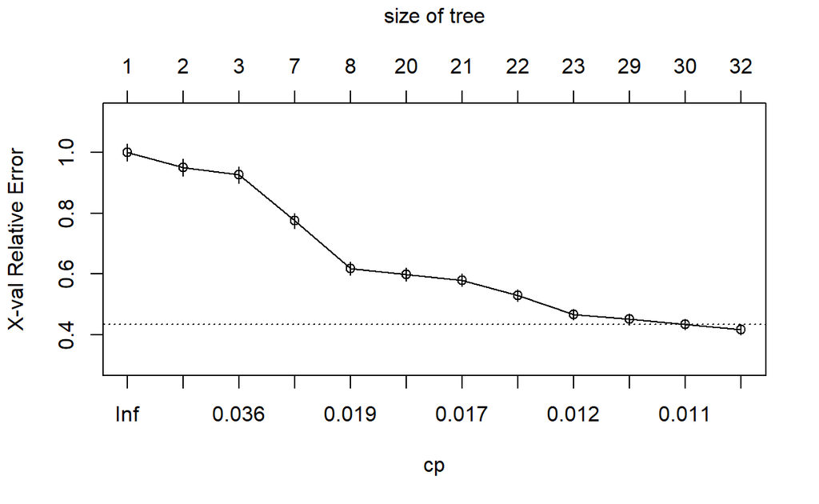

```r
plotcp(m1)
```

Our predicted test error (for within variation only) is ~6.3%, compared to ~12% on the original data.

```r
pred <- predict(m1, newdata = hosp_test)
p_error <- Metrics::rmse(actual = hosp_test$exit_outcome, predicted = pred)
p_error
```

```
[1] 0.06271271
```

We searched over a grid of hyperparameters to find the optimal tree.

```
[1] 0.09376498
```

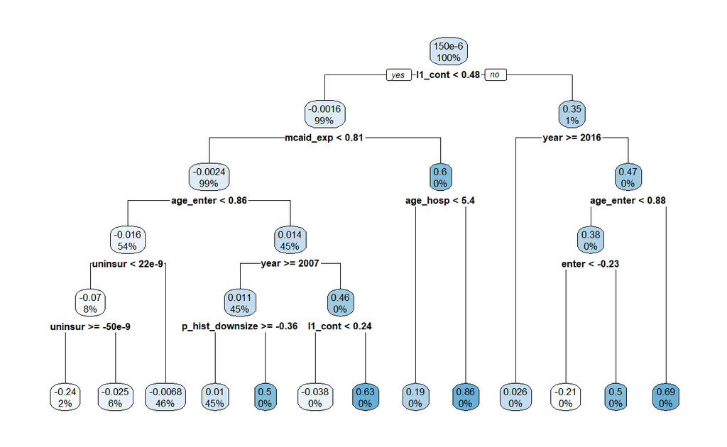

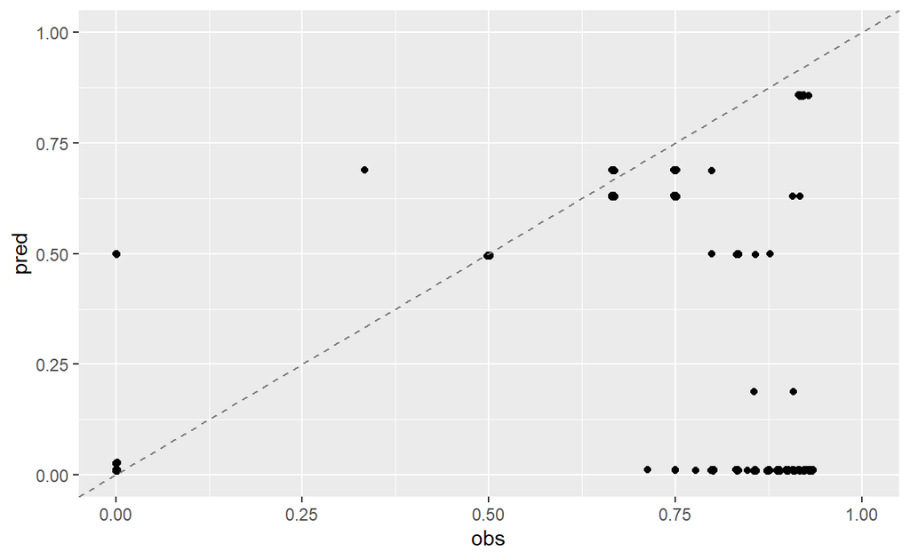

We find it interesting that our “demeaned” tree looks totally different from both our original tree and the REEMtree. It does not seem possible to simply approximate a REEMtree using debiased data.

Interpreting the splits of the **original tree** suggests that larger (total assets) and more profitable (net income margin) hospitals are less likely to close.

The **REEMTree** suggests that hospitals are less likely to close when they are profitable and have lower leverage. Critical access (CAH, i.e., rural) and non-disproportionate share (DSH, i.e., high poverty) hospitals, as well as larger, younger, and those with fewer prior downsizing years are all less likely to close.

Our prediction plot suggests that we are still underpredicting closure, but the model is generally more successful at predicting within rather than total variation.

**2. Random forest**

The out of the box RF on demeaned data gave us an RMSE of 5.7%, compared to 11.9% on the original data.

```r
n_features <- length(setdiff(names(hosp_train), "exit_outcome"))

# create hyperparameter grid
hyper_grid.df <- expand.grid(
  num.trees = c(500, 1000),
  mtry = floor(n_features * c(.01, .05, .3333)),
  min.node.size = c(1, 10, 20),
  rmse = NA
)
```

```r
#create and register cluster
n.cores <- parallel::detectCores() - 1
my.cluster <- parallel::makeCluster(n.cores)
doParallel::registerDoParallel(cl = my.cluster)

#execute grid search in parallel
prediction.error <- foreach(
  num.trees     = hyper_grid.df$num.trees,
  mtry          = hyper_grid.df$mtry,
  min.node.size = hyper_grid.df$min.node.size,
  .combine = 'c',
  .packages = "ranger") %dopar% {

  #fit model
  m.i <- ranger::ranger(
    formula         = exit_outcome ~ .,
    data            = hosp_train,
    num.trees       = num.trees,
    mtry            = mtry,
    min.node.size   = min.node.size,
    verbose         = FALSE,
    seed            = 123,
    respect.unordered.factors = 'order'
  )

  #returning OOB error
  return(sqrt(m.i$prediction.error))
}

hyper_grid.df$prediction.error <- prediction.error

parallel::stopCluster(cl = my.cluster)
```

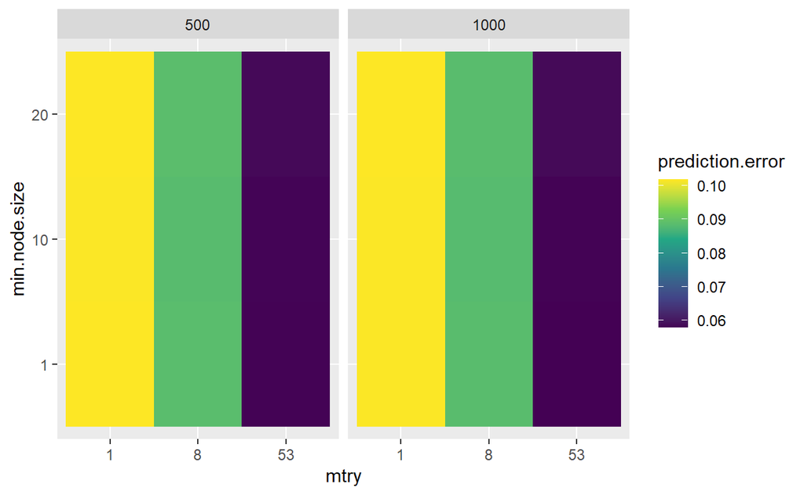

```r
#plot the errors
ggplot2::ggplot(data = hyper_grid.df) +
  ggplot2::aes(
    x = as.factor(mtry),
    y = as.factor(min.node.size),
    fill = prediction.error
  ) +
  ggplot2::facet_wrap(as.factor(hyper_grid.df$num.trees)) +
  ggplot2::geom_tile() +
  ggplot2::scale_y_discrete(breaks = c(1, 10, 20)) +
  ggplot2::scale_fill_viridis_c() +
  ggplot2::xlab("mtry") +
  ggplot2::ylab("min.node.size")
```

```r
#saved as new_tree_tune

#list top 10 models
hyper_grid.df %>%
  arrange(prediction.error) %>%
  head(10)
```

```
   num.trees mtry min.node.size rmse prediction.error
1       1000   53             1   NA       0.05791324
2       1000   53            10   NA       0.05805260
3        500   53             1   NA       0.05811170
4        500   53            10   NA       0.05820289
5        500   53            20   NA       0.05864056
6       1000   53            20   NA       0.05868770
7       1000    8            10   NA       0.08836730
8        500    8            10   NA       0.08850339
9       1000    8             1   NA       0.08858529
10      1000    8            20   NA       0.08858692
```

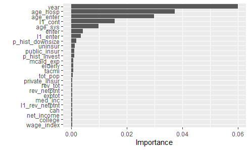

```r
#train a random forest model
rf1 <- ranger(
  exit_outcome ~ .,
  data = hosp_train,
  num.trees = 1000,
  mtry = 36,
  respect.unordered.factors = "order",
  min.node.size = 1,
  seed = 123,
  importance = "permutation"
)
rf1
rf1$variable.importance

p1 <- vip::vip(rf1, num_features = 25, bar = FALSE)
gridExtra::grid.arrange(p1, nrow = 1)
#saved as new_tree_imptc

#RMSE
(default_rmse <- sqrt(rf1$prediction.error))
```

**3. Boosted trees**

Finally, our demeaned boosted model gave an RMSE of 6.4%.

```r
detach("package:REEMtree", unload=TRUE)
library(xgboost)
```

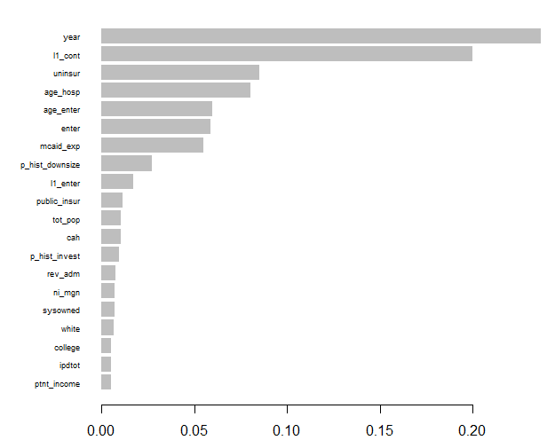

The importance plot suggests that having no prior major changes (l1_cont), the percent of uninsured patients, age, and history of downsizing are key predictors of closure.

In summary, we do not find that tree-based algorithmic models run on demeaned data closely approximate the REEMtree. Overall, our variable importance plots indicate that net income, total assets, leverage, DSH, and CAH status are important predictors of hospital exit.

In our last section, we apply double (debiased) machine learning methods to try to estimate the causal effects of the most “important” variables on hospital exit. (Our discussion is based on Chernozhukov et al. (2018), and our code is based on Kurz’s guest lecture and case study. These analyses are all run on the original data.) We initially assume a partially linear regression model, in which $\theta_0$ is our parameter of interest:

$Y = D\theta_0 + g_0(X) + U, E(U|X,D)=0$

$D = m_0(X) + V, E(V|X)=0$

If we assume that the treatment $D$ is exogenous conditional on the controls $X$, then $\theta_0$ can be interpreted as the causal effect of $D$. The second equation models confounding between the treatment and the controls. The most naive approach to estimation of $\theta_0$ would be to simply difference the treated and untreated means; a more sophisticated (but still naive) ML approach would obtain an estimate of $g_0$ on an auxiliary sample and estimate $\theta_0$ using $g_0$ on the main sample. Based on our variable importance plots, we consider the effects of 6 variables: total assets, net income, debt (to assets), DSH and CAH status, and rural. (Rural is of interest because the prior literature suggests it is a key predictor of financial distress and closure.)

```
   Min. 1st Qu.  Median    Mean 3rd Qu.    Max.
0.00000 0.00000 0.01746 0.13715 0.20217 1.00000
```

Our naive estimator is the unconditional average predictive effect (difference in means), which would only be consistent if treatment were randomly assigned. We retain these estimates for comparison later.

```
[1] 0.08
```

```
[1] -1.44
```

```
[1] -1.26
```

```
[1] -0.05
```

```
[1] -1.19
```

```
[1] -0.06
```

```
<DoubleMLData>
  Public:
    all_variables: year tot_pop white highschool college unempl med_inc uni ...
    clone: function (deep = FALSE)
    d_cols: hi_debt_a
    data: data.table, data.frame
    data_model: data.table, data.frame
    initialize: function (data = NULL, x_cols = NULL, y_col = NULL, d_cols = NULL,
    n_instr: 0
    n_obs: 85811
    n_treat: 1
    other_treat_cols: NULL
    set_data_model: function (treatment_var)
    treat_col: hi_debt_a
    use_other_treat_as_covariate: TRUE
    x_cols: year tot_pop white highschool uninsur elderly poverty mc ...
    y_col: exit_outcome
    z_cols: NULL
```

We set up the data for the ML models, including adding polynomial features in age, total assets, and admissions. For our DoubleML analysis, we use 3 learners: RF, LASSO, and gradient boosted.

*Overcoming regularization biases using orthogonalization:* Chernozhukov et al. propose an orthogonalized regressor obtained by partialling out the effect of $X$ from $D$ to obtain $\hat{V} = D − \hat{m_0(X)}$ using an auxiliary sample. The debiased ML estimator for $\theta_0$ is then obtained using the main sample: $\hat{\theta_0} = (\frac{1}{n} \sum \hat{V_i} D_i)^{-1} (\frac{1}{n} \sum Y_i - \hat{g_0}(Xi))$.

The combination of approximate orthogonalizing, high quality machine learning estimators, and sample-splitting reduces regularization and over-fitting biases to result in an approximately unbiased and normally distributed estimator that can be used for inference.

```r
  #Add polynomial features
  formula_flex = formula(" ~ -1 + poly(age_hosp, 2, raw=TRUE) +  poly(tot_assets, 2, raw=TRUE) + poly(admtot, 2, raw=TRUE) + year + tot_pop + white + highschool + uninsur + elderly + poverty + mcaid_exp + tacmi + age_hosp + bdtot + admtot + teach + mcare + mcaid + tot_services + hrr_sh + uncomp + cash + capex + liquid + bought + sysowned + l1_cont + p_hist_downsize + fp + np")
  features = data.frame(model.matrix(formula_flex, cleaned))

  model_data_debt= data.table("exit_outcome" = cleaned[, exit_outcome], "hi_debt_a"     = cleaned[, hi_debt_a], features)
  model_data_ni  = data.table("exit_outcome" = cleaned[, exit_outcome], "hi_ni_mgn"     = cleaned[, hi_ni_mgn], features)
  model_data_ass = data.table("exit_outcome" = cleaned[, exit_outcome], "hi_tot_assets" = cleaned[, hi_tot_assets], features)
  model_data_dsh = data.table("exit_outcome" = cleaned[, exit_outcome], "dsh"           = cleaned[, dsh], features)
  model_data_cah = data.table("exit_outcome" = cleaned[, exit_outcome], "cah"           = cleaned[, cah], features)
  model_data_rur = data.table("exit_outcome" = cleaned[, exit_outcome], "rural"         = cleaned[, rural], features)

  #Initialize DoubleMLData (data-backend of DoubleML)
  #data_dml_flex = DoubleMLData$new(model_data, y_col = "net_tfa", d_cols = "e401")
  data_dml_flex_debt = DoubleMLData$new(model_data_debt, y_col = "exit_outcome", d_cols = "hi_debt_a")
  data_dml_flex_ni   = DoubleMLData$new(model_data_ni  , y_col = "exit_outcome", d_cols = "hi_ni_mgn")
  data_dml_flex_ass  = DoubleMLData$new(model_data_ass , y_col = "exit_outcome", d_cols = "hi_tot_assets")
  data_dml_flex_dsh  = DoubleMLData$new(model_data_dsh , y_col = "exit_outcome", d_cols = "dsh")
  data_dml_flex_cah  = DoubleMLData$new(model_data_cah , y_col = "exit_outcome", d_cols = "cah")
  data_dml_flex_rural= DoubleMLData$new(model_data_rur , y_col = "exit_outcome", d_cols = "rural")

  #****************************
  data_dml <- cleaned_dml_rur
  data_dml_flex <- data_dml_flex_rural
  #****************************

  #Use a RF learner
  ml_g_random_forest = lrn("regr.ranger")
  ml_m_random_forest_class = lrn("classif.ranger")

  set.seed(123)
  dml_plr = DoubleMLPLR$new(data_dml,
  ml_g = ml_g_random_forest,
  ml_m = ml_m_random_forest_class,
  n_folds = 3)
  print(dml_plr)
  dml_plr$fit()
  dml_plr$summary()

  forest_plr_rur         = dml_plr$coef
  forest_std_plr_rur     = dml_plr$se
  forest_confint_plr_rur = dml_plr$confint()


  #Use a LASSO learner
  # Initialize learners
  # lambda.min = choose the optimal lambda (which maximizes the cross-validated auc)
  set.seed(123)
  lasso = lrn("regr.cv_glmnet", nfolds = 5, s = "lambda.min")
  lasso_class = lrn("classif.cv_glmnet", nfolds = 5, s = "lambda.min")
  # Initialize DoubleMLPLR model
  dml_plr = DoubleMLPLR$new(data_dml_flex,
  ml_g = lasso,
  ml_m = lasso_class,
  n_folds = 3)
  dml_plr$fit()
  dml_plr$summary()

  lasso_plr_rur         = dml_plr$coef
  lasso_std_plr_rur     = dml_plr$se
  lasso_confint_plr_rur = dml_plr$confint()


  #Use a gradient boosted learner
  #Boosting
  boost = lrn("regr.xgboost", objective = "reg:squarederror")
  boost_class = lrn("classif.xgboost", objective = "binary:logistic",
  eval_metric = "logloss")
  set.seed(123)
  dml_plr = DoubleMLPLR$new(data_dml,
  ml_g = boost,
  ml_m = boost_class,
  n_folds = 3)
  dml_plr$fit()
  dml_plr$summary()

  boost_plr_rur         = dml_plr$coef
  boost_std_plr_rur     = dml_plr$se
  boost_confint_plr_rur = dml_plr$confint()


  #result summary
  result_plr_rur = data.table("model" = "plr",
  "ML" = c("naive", "glmnet", "ranger", "xgboost"),
  "Estimate" = c(APE_uncond_rur,lasso_plr_rur,forest_plr_rur,boost_plr_rur),
  "lower" = c(APE_uncond_rur,lasso_confint_plr_rur[1], forest_confint_plr_rur[1], boost_confint_plr_rur[1]),
  "upper" = c(APE_uncond_rur,lasso_confint_plr_rur[2], forest_confint_plr_rur[2], boost_confint_plr_rur[2]))
  result_plr_rur
```

We plot the results from our naive and Double ML models below for each variable of interest.

**High debt to assets**

Having a high debt to assets ratio appears to increase the probability of closure but cannot be statistically distinguished from 0. Interestingly, the naive estimates and those obtained by LASSO and boosted models are quite similar.

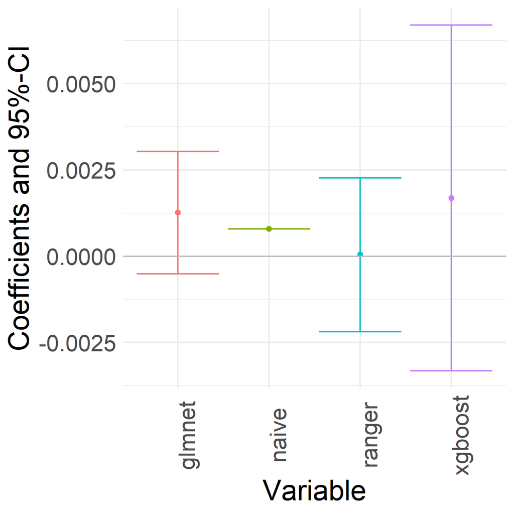

**High net income**

The estimates for net income are significantly negative and suggest that having an above median net income margin decreases the probability of closure by ~1pp. These effects are very large relative to the average probability of closing of 1.6%.

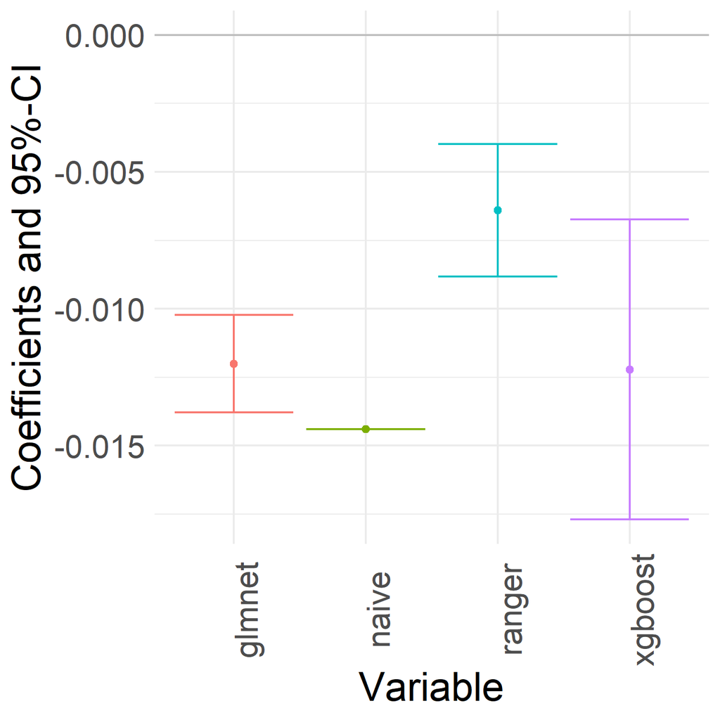

**Size (high total assets)**

These estimates suggest that being a larger hospital significantly decreases the probability of closing by ~0.5-1pp.

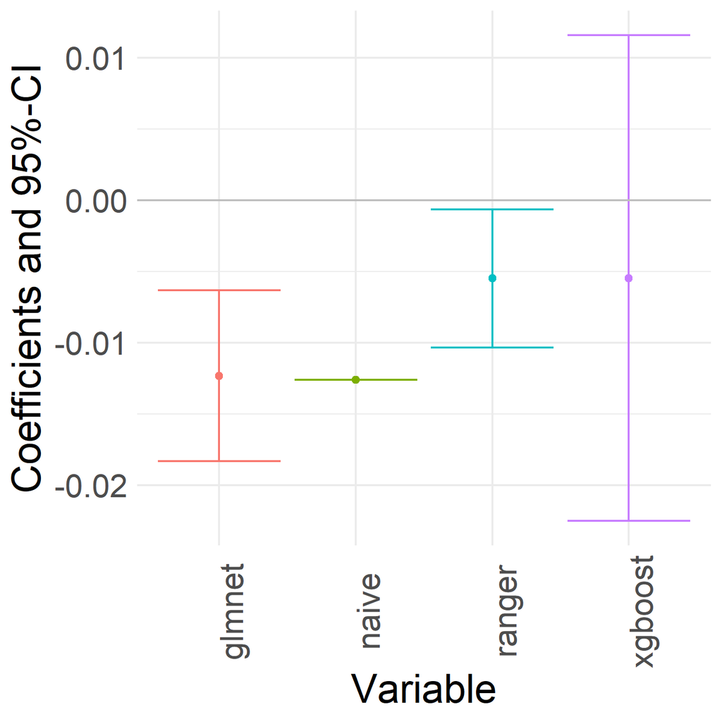

**DSH (high-poverty or disproportionate share hospital)**

DSH estimates are significant, large, and positive: they suggest that being a DSH hospital increases the probability of closure by 1 to 3.5pp (using the DoubleML methods). In contrast, the naive estimator finds an effect close to 0.

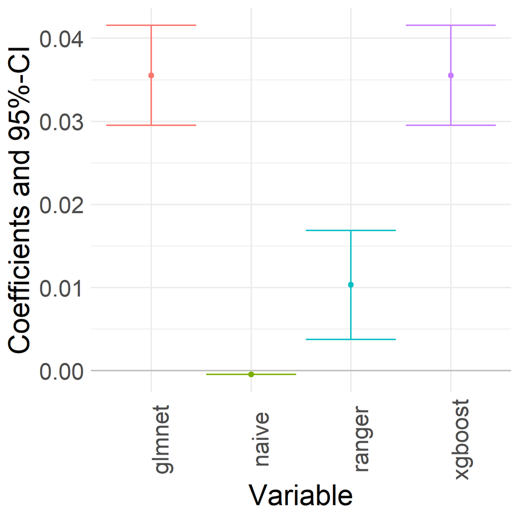

**CAH (targeted rural or critical access hospital)**

The CAH estimates are implausibly large for LASSO and xgboost, and perhaps more believable for RF.

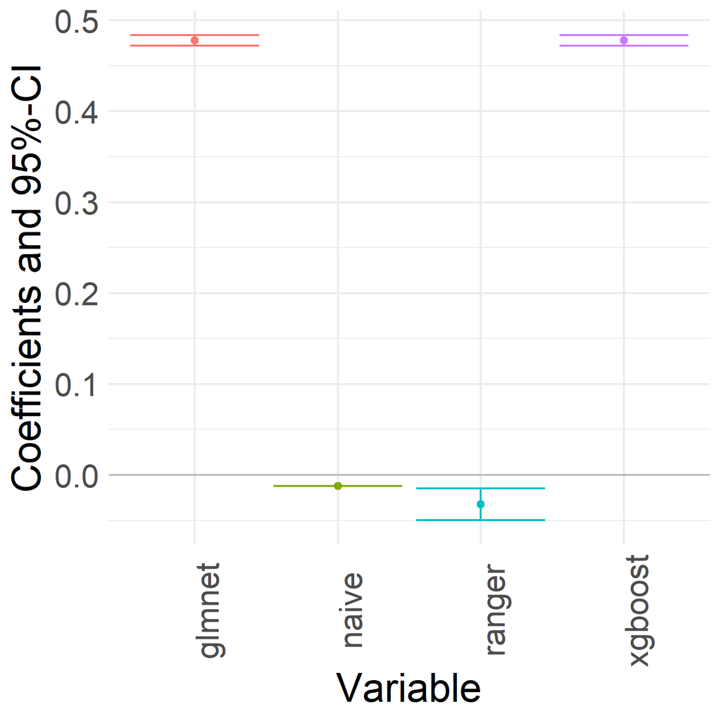

**Rural**

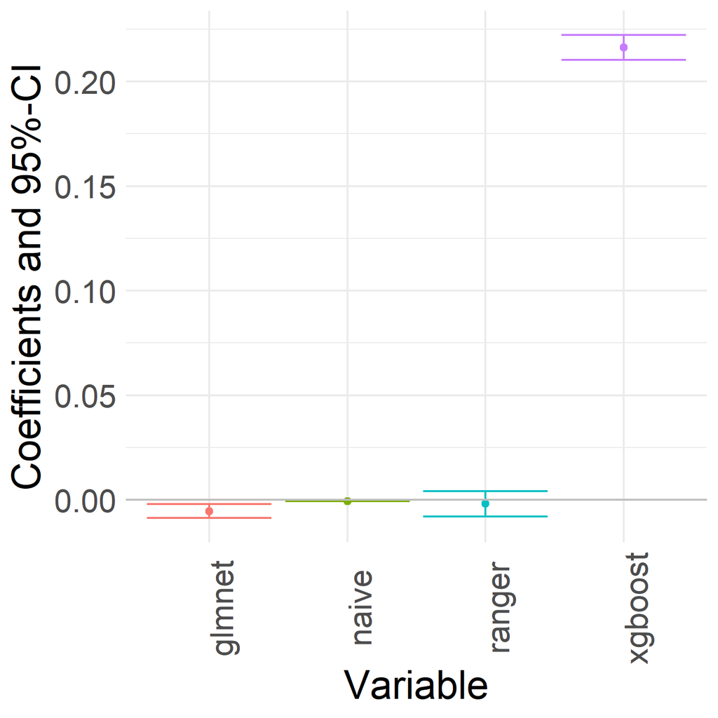

We also relaxed our assumption of a partially linear model to allow for fully heterogeneous treatment effects: $Y = g_0(D,X) + e$, with the other assumptions as before.

```r
  #To reduce the disproportionate impact of extreme propensity score weights in the interactive model we trim the propensity scores which are close to the bounds.

  #****************************
  data_dml <- cleaned_dml_debt
  data_dml_flex <- data_dml_flex_debt
  #****************************
  # LASSO
  # Initialize learners
  set.seed(123)
  # Initialize DoubleMLIRM model
  dml_irm = DoubleMLIRM$new(data_dml_flex,
  ml_g = lasso,
  ml_m = lasso_class,
  trimming_threshold = 0.01,
  n_folds = 3)
  dml_irm$fit()
  dml_irm$summary()

  lasso_irm_debt         = dml_irm$coef
  lasso_std_irm_debt     = dml_irm$se
  lasso_confint_irm_debt = dml_irm$confint()


  #RF
  # Random Forest
  ml_g_random_forest = lrn("regr.ranger")
  ml_m_random_forest_class = lrn("classif.ranger")

  set.seed(123)
  dml_irm = DoubleMLIRM$new(data_dml,
  ml_g = ml_g_random_forest,
  ml_m = ml_m_random_forest_class,
  trimming_threshold = 0.01,
  n_folds = 3)
  dml_irm$fit()
  dml_irm$summary()

  forest_irm_debt         = dml_irm$coef
  forest_std_irm_debt     = dml_irm$se
  forest_confint_irm_debt = dml_irm$confint()


  # Boosting
  set.seed(123)
  dml_irm = DoubleMLIRM$new(data_dml,
  ml_g = boost,
  ml_m = boost_class,
  trimming_threshold = 0.01,
  n_folds = 3)
  dml_irm$fit()
  dml_irm$summary()

  boost_irm_debt         = dml_irm$coef
  boost_std_irm_debt     = dml_irm$se
  boost_confint_irm_debt = dml_irm$confint()
```

**High debt to assets**

Our debt estimates look remarkably similar to the partially linear model, although the ranger estimate is now positive and significantly different from 0.

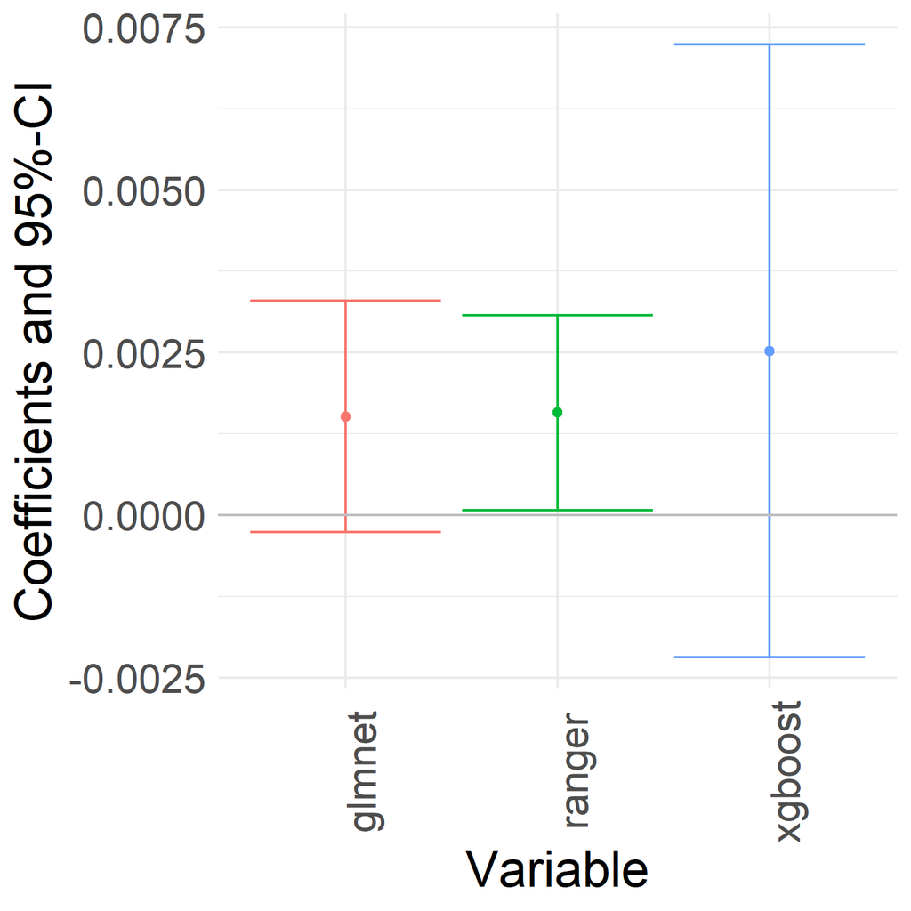

In summary, our point estimates for the 6 important variables are logical (and in line with what economic theory would predict). The DoubleML methods deliver estimates that are often significantly different from the naive ones, but ultimately rely on the assumption of conditional treatment exogeneity. This assumption may not be valid given our setting and controls.

## Conclusion

Our first CART tree suggested that hospital size and profitability were the most important variables for predicting closure, which was both reassuring and obvious. It also lent strong support for the hypothesis that hospitals exit based on factors related to expected profitability. We have been able to explore some of the benefits of other algorithmic models, particularly ones designed for panel data (such as REEMTree) to add nuance to this initial finding.

While variable importance plots and Double machine learning suggest that net income and size have large estimated effects on hospital closure, DSH and CAH status are also of first order importance. In certain models, dynamic factors such as age and history of downsizing are also important. We find limited support for the “liquidity constraint” hypothesis: debt is often important but has small estimated effects on closure. In contrast to the prior literature, we do not find that being located in a rural area is an important predictor of closure.